# Dean Tesler - 316167105, Gil Shilo - 315440230

```r
# Read data
fashion_mnist = read.csv("C:/Users/97254/OneDrive/שולחן העבודה/lab_4/fashion-mnist_train.csv")
fashion_mnist_te =  read.csv("C:/Users/97254/OneDrive/שולחן העבודה/lab_4/fashion-mnist_test.csv")

# Keep only pullovers (2) and coats (4)

pull_and_coats = fashion_mnist %>% filter( label %in% c(2,4))
pull_and_coats_te = fashion_mnist_te %>% filter( label %in% c(2,4))

# Viewing function.
view_image = function(k, dat = pull_and_coats[,-1],col_map = grey.colors(256)){
  im = dat[k,]
  image(matrix(as.numeric(im), nc = 28)[,28:1]/256, col = col_map)
}

train_response = factor(pull_and_coats[,1],)
train_feat = pull_and_coats[,-1]
test_response = factor(pull_and_coats_te[,1],)
test_feat = pull_and_coats_te[,-1]
```

## Question 1

In this question we were asked to use different classifiers.

# A

The first classify we choose is random forest. The reason why we choose random forest is because it is a good algorithm to work with big data sets. Because it uses multiply decision trees it is high accurated.

```r
set.seed(1)
rf_method <- randomForest(as.factor(train_response) ~., data = train_feat, ntree = 200, importance = TRUE, type = 'classification')
rf_train_pred_test <- predict(object = rf_method, newdata = train_feat, type= 'prob')[,2]
rf_train_pred <- ifelse(rf_train_pred_test < 0.5,'2','4')
rf_test_pred_test <- predict(object = rf_method, newdata = test_feat,type= 'prob')[,2]
rf_test_pred <- ifelse(rf_test_pred_test < 0.5,'2','4')
```

# B

The second classify we choose is naive Bayes classifier. The reason why we choose naive Bayes is because it is among the simplest Bayesian network models and can run fast in a linear time and it can achieve high accuracy.

```r
set.seed(1)
nb_method <- naive_bayes(as.factor(train_response) ~ ., data = train_feat, usekernel = F)
nb_train_pred_test <- predict(nb_method, newdata = train_feat,type= 'prob')[,2]
nb_train_pred <- ifelse(nb_train_pred_test < 0.5,'2','4')
nb_test_pred_test <- predict(nb_method, newdata = test_feat,type= 'prob')[,2]
nb_test_pred <- ifelse(nb_test_pred_test < 0.5,'2','4')
```

## Question 2

```r
## we will use T - true, F - false, P - positive, N- negative
func_q2 <- function(vec_test, vec_pred_test){
T_P <- sum((vec_test == '2') & (vec_pred_test == '2'))
T_N <- sum((vec_test == '4') & (vec_pred_test == '4'))
F_P <- sum((vec_test == '4') & (vec_pred_test == '2'))
F_N <- sum((vec_test == '2') & (vec_pred_test == '4'))
confusion_matrix <- rbind(c(T_N, F_N),c(F_P, T_P))
colnames(confusion_matrix) <- c("0","1")
rownames(confusion_matrix) <- c("0","1")
precision <- T_P / (T_P + F_P)
recall <- T_P / (T_P + F_N)
specificity = T_N / (T_N + F_P)

return(list('Precision' = precision, 'Recall' = recall,'Specificity'= specificity, 'Confusion Matrix' = confusion_matrix))
}

table_matrix <- matrix (nrow=4,ncol = 2)
rownames(table_matrix) <- c('random forest train','random forest test','naive bayes train', 'naive bayes test')
colnames(table_matrix) <- c('Precision','Recall')

rf_train <- func_q2(train_response, rf_train_pred)
rf_test <- func_q2(test_response, rf_test_pred)
nb_train <- func_q2(train_response, nb_train_pred)
nb_test <- func_q2(test_response, nb_test_pred)


knitr::kable(rf_test$`Confusion Matrix`, caption = 'random forest confusion matrix')
```

random forest confusion matrix

|  | 0 | 1 |
| --- | --- | --- |
| 0 | 931 | 138 |
| 1 | 69 | 862 |

```r
knitr::kable(nb_test$`Confusion Matrix`, caption = 'naive bayes confusion matrix')
```

naive bayes confusion matrix

|  | 0 | 1 |
| --- | --- | --- |
| 0 | 945 | 606 |
| 1 | 55 | 394 |

```r
table_matrix[1,1] <- rf_train$Precision
table_matrix[1,2] <- rf_train$Recall
table_matrix[2,1] <- rf_test$Precision
table_matrix[2,2] <- rf_test$Recall
table_matrix[3,1] <- nb_train$Precision
table_matrix[3,2] <- nb_train$Recall
table_matrix[4,1] <- nb_test$Precision
table_matrix[4,2] <- nb_test$Recall
knitr:: kable(table_matrix)
```

|  | Precision | Recall |
| --- | --- | --- |
| random forest train | 1.0000000 | 1.0000000 |
| random forest test | 0.9258861 | 0.8620000 |
| naive bayes train | 0.8567073 | 0.3746667 |
| naive bayes test | 0.8775056 | 0.3940000 |

When looking at the results it is easy to to say which of the methods is doing better in terms of test set results, and magnitude of over fitting. When looking at the test set results we can see that in both methods the precision is high (even though in the random forest it is a bit higher),but there is a very big different in the recall value. we can say that in this section random forest method takes the lead. The precision in the random forest is very high and in the train set it always predicts the right close. Also on the over fitting side it is pretty clear that the random Forrest is better.

Over all the random forest method is better in this scenario.

## Question 3

```r
rf_prob <- predict(object = rf_method, newdata = test_feat, type = 'prob')[,1]

nb_prob <- predict(object = nb_method, newdata = test_feat, type = 'prob')[,1]

roc_function <- function(labels, scores){
threshold <- seq(0, 1, 0.01)
new_table <- data.frame(matrix(ncol = 3, nrow = 0))
names(new_table) <- c('threshold','specificity','sensitivity')
for (i in 1:length(threshold)){
  y <- ifelse(scores <= threshold[i] ,"4" ,"2")
  c = func_q2(labels, y)
  new_table[i,] <- c(threshold[i], 1 - c$Specificity, c$Recall)}
  return(new_table)
}
```

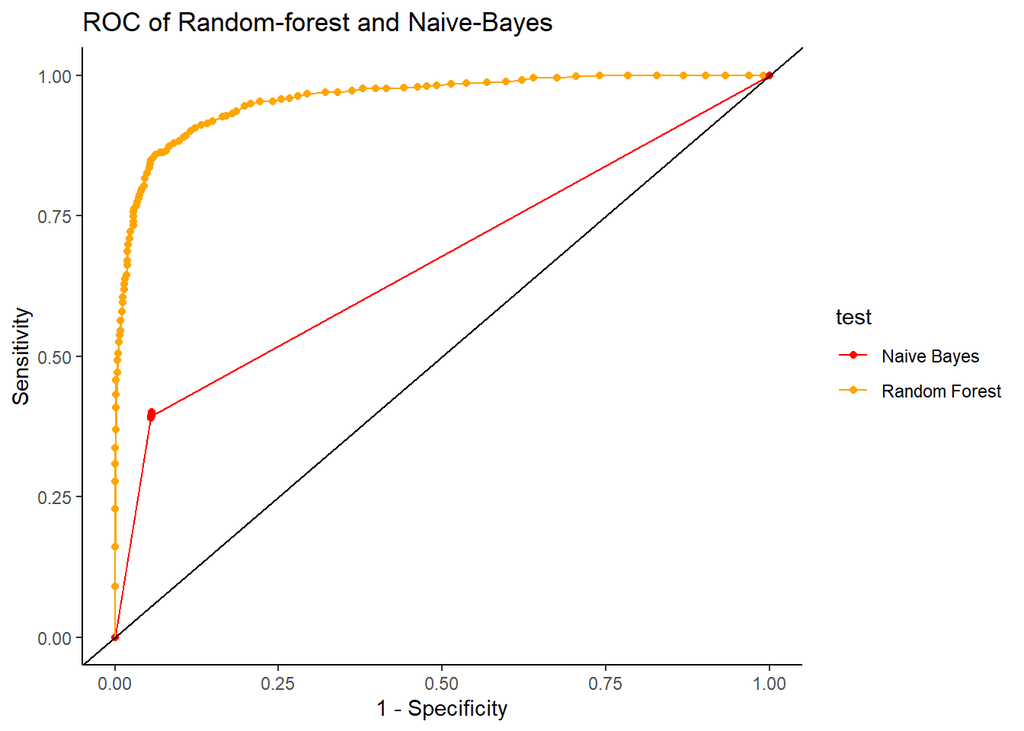

```r
roc_table_RF <- roc_function(test_response, rf_prob)
roc_table_NB <- roc_function(test_response, nb_prob)

roc_join <- rbind(roc_table_RF, roc_table_NB)
roc_join$test <- rep(c('Random Forest', 'Naive Bayes'), c(101,101))

ggplot(data = roc_join ,aes(x= specificity, y = sensitivity, col = test )) + geom_point() + geom_line() + geom_abline(slope = 1,intercept = 0) + labs(title = 'ROC of Random-forest and Naive-Bayes', x = "1 - Specificity", y = 'Sensitivity') + theme_classic() +
scale_color_manual(values = c('red', 'orange'))
```

From the graph we can see that naive-bayes is a linear line that got a change of the slope at around 0.4 sensvity compare to the random forest who is non-linear. We can see that random forest is performing better than the naive bayes.

## Question 4

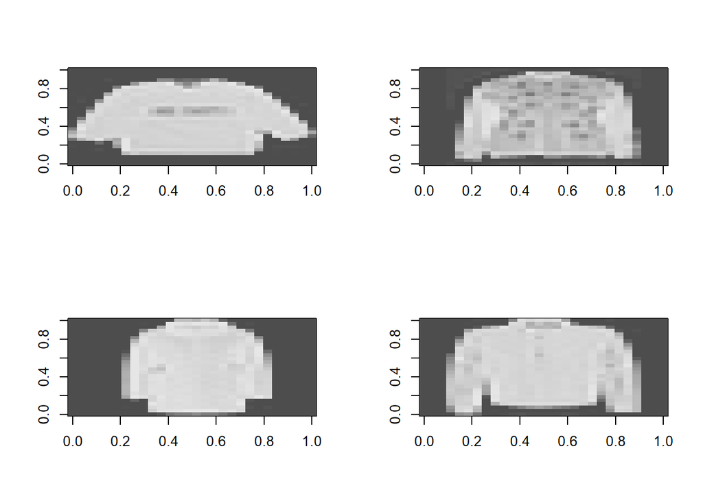

```r
df <- data.frame(cbind(test_response, rf_test_pred))
do_not_match <- df[df$test_response != df$rf_test_pred, ]
ind_dont_match <- as.numeric(rownames(do_not_match))
par(mfrow=c(2,2))
for (i in 1:4) {
  view_image(ind_dont_match[i])}
```

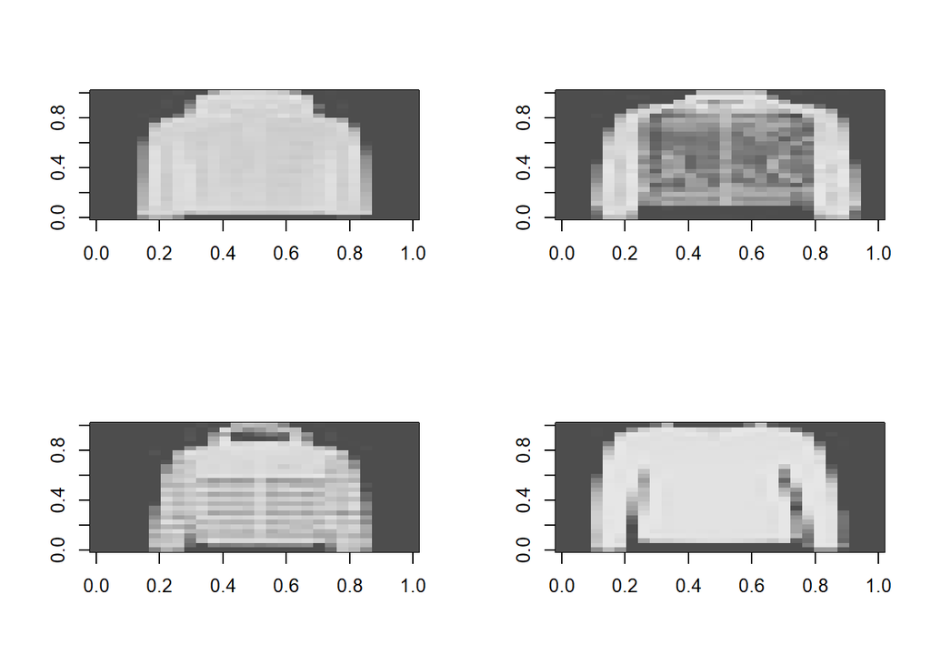

```r
df_q4 <- data.frame(cbind(pull_and_coats_te$label,rf_test_pred))
wrong_pred_rf <- df_q4[which((pull_and_coats_te$label!=rf_test_pred)),]
image_num <- row.names(wrong_pred_rf)
par(mfrow = c(2,2))
view_image(image_num[1])
view_image(image_num[6])
view_image(image_num[25])
view_image(image_num[40])
```

We choose to take the random forest method due to the questions before that we found that this methods fits better. The 4 images above are images that were classified incorrectly. The 2 images int he first row are pullovers that were classified as coats. And the 2 images in the second row are coats that were classified as pullovers. We can see that in all 4 images the “hand” section is very blurry so as an result it is hard to identify because there is a difference in hand part for pullovers and coats. For the first image it looks like a big and heavy figure which is more likely in a coat. For the second image the sleeves look heavier then in an usual pullover and has more of a look of an coat. For the third image the neck/head section has a look of a hoodie which is more likely in a pullover so it, so it is harder to classify as an coat. In the fourth image it looks like a lite top an in a smaller figure which is more likely in an pullover.